# Statistical methods in quantitative genetics

Genetic group models and marker-based regression

Stefanie Muff, CBD, Department of Mathematical Sciences, NTNU

CAS Oslo, March 17 2020

## Overview

$~$

- Genetic group models
  - Differences in means
  - Differences in additive genetic variance (VA)
- Marker-based regression using genomic data

## How I became an ecological statistician

$~$

$\rightarrow$ Master in mathematics

$\rightarrow$ PhD in computational structural biology

$\rightarrow$ Certificate of Advanced Studies in applied statistics

$\rightarrow$ Postdoc in medical and ecological statistics

$\rightarrow$ Since Sept. 2019: Associate Professor in Statistics, CBD, Department of Mathematical Sciences, NTNU Trondheim

$~$

I’m often not sure if I am

- a mathematician?
- a biostatistician?
- an ecological statistician?
- an applied statistician?

## Research interests

$~$

$~$

$~$

$~$

# Part I: Genetic group animal models

## The basic animal model

$~$

- Given phenotypic measurements $y_i$ for individuals $1\leq i \leq n$, the most simple form of the animal model is
  $$\begin{equation*}
  y_i = \mu + a_i + e_i \ ,
  \end{equation*}$$
  where $e_i \sim \text{N}(0,\sigma_E^2)$ and ${\mathbf a}^\top = (a_1, \ldots, a_n)^\top \sim \text{N}({\mathbf a},\sigma_A^2 \mathbf{A})$ with additive genetic variance $\sigma_A^2$ and additive genetic relatedness matrix $\mathbf{A}$.

$~$

- The model can be extended by additional fixed or random effects.  
  $~$
- **Assumptions**:
  - All individuals derive from the same genetic population.
  - The breeding values ($a_i$) encode for the deviation from the mean of this population and thus have an expected value $\text{E}[a_i]=0$.

## Systematic deviation from the assumptions

$~$

For example

- in cross-bred livestock.
- when genetically different wild subpopulations mix (migration).

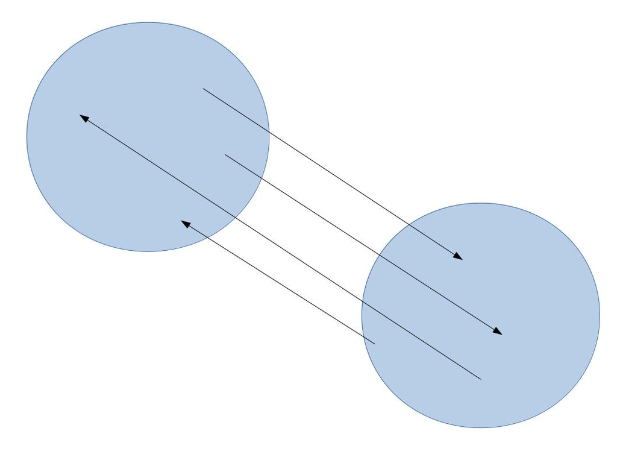

$~$

**Consequence**: Biased estimates of $\sigma_A^2$ and breeding values.

## Genetic group models

$~$

Great overview by Wolak and Reid (2017)

[figure not shown]

$~$ $~$

**Idea**: Allow for ``founder populations’’ that differ in the *mean breeding value*.

### Example for two isolated groups

$~$

Simple model for a phenotypic trait $y_i$ with mean $\mu$, breeding values $a_i$ and environmental component $e_i$:

$$\begin{align*}
&\text{group 1:} \hspace{-14mm} & y_i &= \mu + \underbrace{a_i}_{u_i} + e_i \ ,\\
&\text{group 2:} \hspace{-14mm} & y_i &= \mu + \underbrace{g_2 + a_i}_{u_i} + e_i \ ,
\end{align*}$$
thus

$$u_i \sim \text{N}(0,\sigma_A^2 \mathbf{A}) \quad \text{in group 1}.$$
$$u_i \sim \text{N}(g_2,\sigma_A^2 \mathbf{A}) \quad \text{in group 2}.$$
$~$

- **Interpretation:** The total additive genetic effects $u_i$ (thus probably also the mean phenotypic values) differ between the two groups.
- **Example:** Systematic differences in wing length, weight,…

General formulation of genetic group model with $r$ groups
$$\begin{equation*}
y_i = \mu + \underbrace{\sum_{j=1}^r q_{ij}g_j + a_i}_{u_i} + e_i \ , \quad \mathbf{a}^\top \sim \text{N}(\mathbf{0},\sigma_A^2\mathbf{A}) \ ,
\end{equation*}$$

$~$ $~$

How do we obtain the $q_{ij}$?

### Example

$~$

- Group 1: Founders nodes 1 and 2
- Group 2: Founder node 3

$~$

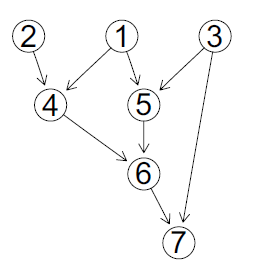

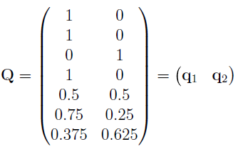

**How to?** E.g. by using the `ggcontrib()` function from the `nadive` R package (Wolak 2012).

## Genetic group models for heterogeneous variances

$~$

- **Caveat:** Additive genetic variances $\sigma_A^2$ are assumed the same within the groups.
- **Idea**: Replace
  $$\begin{align*}
  y_i &= \mu + \sum_{j=1}^r q_{ij}g_j + \textcolor{red}{a_i} + e_i & (\text{homogeneous } \sigma_A^2) \quad\\
  \text{by} \\[2mm]
  y_i &= \mu + \sum_{j=1}^r q_{ij}g_j + \textcolor{red}{\sum_{j=1}^r a_{ij}} + e_i \ , & (\text{heterogeneous } \sigma_{A_j}^2)
  \end{align*}$$
  where $(a_{1j}, \ldots, a_{nj})^\top \sim \text{N}(0, \sigma_{A_j}^2 \mathbf{A}_j)$.
- **Two challenges**:
  1. Segregation variances between the groups.
  2. Finding the group-specific relatedness matrics $\mathbf{A}_j$.

Addressing these challenges was the purpose of this publication:

[figure not shown]

## Challenge 1: Segregation variances

$~$

In principle, we would need to “blow up” our models with segregation variances (e.g., García-Cortés and Toro 2006). In our notation:
$$y_i = \mu + \sum_{j=1}^r q_{ij}g_j + \sum_{j=1}^r a_{ij} + \sum_{j < k} s^{(jk)}_i + e_i \ ,$$
$$\mathbf{s}^{(12)}\sim \text{N}(\mathbf{0},\sigma_{s_{12}}^2 \mathbf{A}_{12}) \ ,$$
thus we would need to estimate $r + \left( \begin{matrix} r\\ 2 \end{matrix}\right)$ variances.

**But is this relevant here?**

- The segregation variance when crossing two genetic groups (e.g., breeds) can be computed as
  $$\sigma_S^2 =\frac{1}{2} \sum_{i=1}^m (\alpha_i^c)^2 \ ,$$
  where $\alpha_i^c$ denotes the mean additive genetic difference between the groups due to locus $i$ (Lynch and Walsh, 1998), and $m$ is the number of loci that determine the trait.

$~$

- Why can we safely ignore $\sigma_S^2$ in many setups?

## Under the *infinitesimal model* assumption, all $\alpha_i^c$ are very small, and thus $\sigma_S^2 \approx 0$.

## Challenge 2: Finding group-specific relatedness matrices $\mathbf{A}_j$

$~$

- To understand how to obtain the $\mathbf{A}_j$s, let us recall some properties about the pedigree-based relatedness matrix $\mathbf{A}$.

$~$

- Following Henderson (1976), we can decompose $\mathbf{A}$ by a *generalized Cholesky decomposition* into
  $$\mathbf{A} = \mathbf{T} \mathbf{D} \mathbf{T}' \ ,$$
  with lower triangular matrix $\mathbf{T}$ and transposed $\mathbf{T}'$, and diagonal matrix $\mathbf{D}=\text{Diag}(d_{11},\ldots , d_{nn})$.

$~$

- $\mathbf{T}$ traces the flow of alleles from one generation to the other.

$~$

- The diagonal entries of $\mathbf{D}$ scale the Mendelian sampling variance.

### Example

$~$

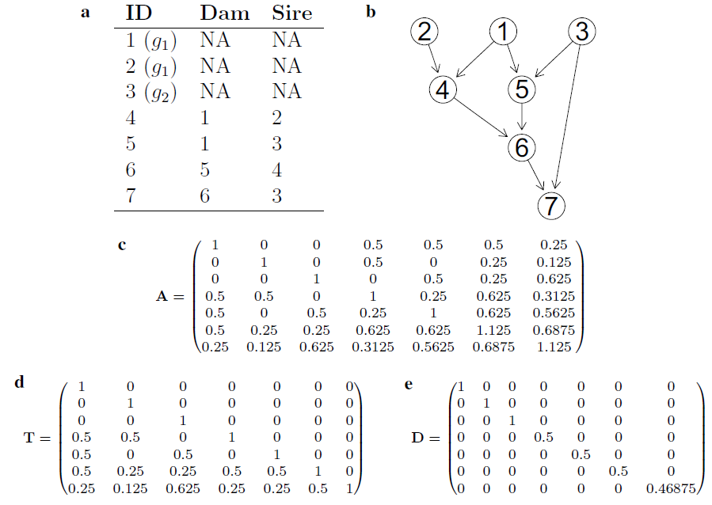

## Basic idea

$~$

Find $\mathbf{A}_j$ by deriving group-specific versions $\mathbf{T}_j$ and $\mathbf{D}_j$ and then use that

$$\mathbf{A}_j = \mathbf{T}_j \mathbf{D}_j \mathbf{T}_j ' \ .$$

## Computations

$~$

- Deriving $\mathbf{T}_j$ and $\mathbf{D}_j$ from $\mathbf{T}$ and $\mathbf{D}$ is cheap (simple algebraic transformations).

$~$

- All operations can also directly be carried out using the Cholesky decomposition of $\mathbf{A}^{-1}$.

$~$

- Models can be fitted with ingegrated nested Laplace approximations (INLA, Rue, Martino, and Chopin 2009) or MCMC (using e.g., MCMCglmm, Hadfield 2010).